# An introduction to Momocs

### `CLUST`: Hierarchical clustering

A hierarchical classification now. It relies on `dist` + `hclust` + `ape::plot.phylo`.

```r
CLUST(bot.p, ~type)
```

[output not shown]

Monophyly is plotted by default. Many options can be found in `?CLUST`

### `KMEANS`: K-means clustering

A very minimal k-means clustering is implemented:

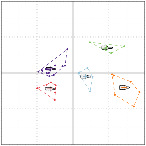

```
## K-means clustering with 5 clusters of sizes 5, 5, 6, 6, 18
##
## Cluster means:
##           PC1          PC2
## 1  0.02497106 -0.006671549
## 2  0.06730453  0.050371247
## 3 -0.04573875 -0.031541607
## 4  0.10184224 -0.028875902
## 5 -0.04433327  0.008000365
##
## Clustering vector:
##         brahma          caney         chimay         corona    deusventrue
##              3              5              4              5              5
##          duvel   franziskaner     grimbergen        guiness     hoegardeen
##              4              3              1              1              5
##        jupiler     kingfisher       latrappe lindemanskriek    nicechouffe
##              5              5              4              5              5
##     pecheresse   sierranevada     tanglefoot          tauro      westmalle
##              5              1              4              5              5
##          amrut    ballantines      bushmills         chivas        dalmore
##              5              4              3              2              2
##   famousgrouse    glendronach   glenmorangie   highlandpark    jackdaniels
##              3              5              5              4              1
##             jb  johnniewalker       magallan     makersmark           oban
##              5              3              3              2              5
##     oldpotrero      redbreast         tamdhu     wildturkey         yoichi
##              2              2              5              5              1
##
## Within cluster sum of squares by cluster:
## [1] 0.001916822 0.002720829 0.001860776 0.006121728 0.006537571
##  (between_SS / total_SS =  89.4 %)
##
## Available components:
##
## [1] "cluster"      "centers"      "totss"        "withinss"     "tot.withinss"
## [6] "betweenss"    "size"         "iter"         "ifault"
```

```r
KMEANS(bot.p, centers = 5)
```

### `MSHAPES`: Mean shapes

We can retrieve the mean shapes, group wise (if a `fac` is specified), or the global mean shape (if omitted). It works from the `Coe` object:

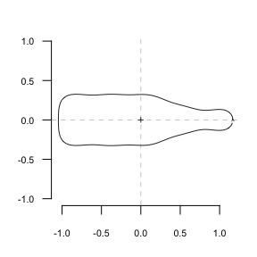

```r
# mean shape
bot.f %>% MSHAPES() %>% coo_plot()
```

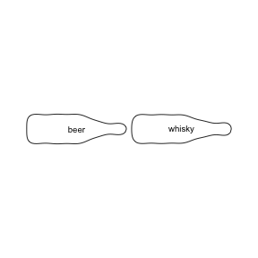

```r
# mean shape, per group
bot.ms <- MSHAPES(bot.f, ~type)
# lets rebuild an Out
Out(bot.ms$shp) %>% panel(names=TRUE)
```

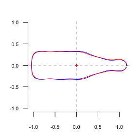

```r
# or individual shapes
beer   <- bot.ms$shp$beer    %>% coo_plot(border="blue")
whisky <- bot.ms$shp$whisky  %>% coo_draw(border="red")
```

We can also plot a pairwise comparison of them:

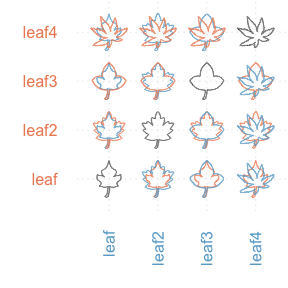

```r
leaves <- shapes %>% slice(grep("leaf", names(shapes))) %$% coo
leaves %>% plot_MSHAPES()
```

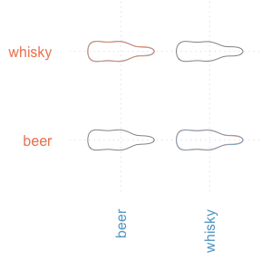

```r
# or from mshapes directly
bot %>% efourier(6) %>% MSHAPES(~type) %>% plot_MSHAPES()
```

## Manipulating objects

One common yet boring task of morphometrics consists in handling datasets: add new information, remove some individuals, etc.

Momocs adapts dplyr verbs to its objects, and add new ones. If you have never heard of dplyr, let’s have a look to its introduction [there](https://CRAN.R-project.org/package=dplyr), this may change your (R) life.

```r
data(olea)
olea
```

```
## Opn (curves)
##   - 210 curves, 99 +/- 4 coords (in $coo)
##   - 4 classifiers (in $fac):
## # A tibble: 210 × 4
##   var   domes view  ind
##   <fct> <fct> <fct> <fct>
## 1 Aglan cult  VD    O10
## 2 Aglan cult  VL    O10
## 3 Aglan cult  VD    O11
## 4 Aglan cult  VL    O11
## 5 Aglan cult  VD    O12
## 6 Aglan cult  VL    O12
## # … with 204 more rows
##   - also: $ldk
```

### `mutate`: add new columns

```r
mutate(olea, fake=factor(rep(letters[1:2], each=105)))
```

```
## Opn (curves)
##   - 210 curves, 99 +/- 4 coords (in $coo)
##   - 5 classifiers (in $fac):
## # A tibble: 210 × 5
##   var   domes view  ind   fake
##   <fct> <fct> <fct> <fct> <fct>
## 1 Aglan cult  VD    O10   a
## 2 Aglan cult  VL    O10   a
## 3 Aglan cult  VD    O11   a
## 4 Aglan cult  VL    O11   a
## 5 Aglan cult  VD    O12   a
## 6 Aglan cult  VL    O12   a
## # … with 204 more rows
##   - also: $ldk
```

### `slice`: select individuals based on their position

```r
slice(olea, 1:5)
```

```
## Opn (curves)
##   - 5 curves, 99 +/- 4 coords (in $coo)
##   - 4 classifiers (in $fac):
## # A tibble: 5 × 4
##   var   domes view  ind
##   <fct> <fct> <fct> <fct>
## 1 Aglan cult  VD    O10
## 2 Aglan cult  VL    O10
## 3 Aglan cult  VD    O11
## 4 Aglan cult  VL    O11
## 5 Aglan cult  VD    O12
##   - also: $ldk
```

```r
slice(olea, -(1:100))
```

```
## Opn (curves)
##   - 110 curves, 99 +/- 4 coords (in $coo)
##   - 4 classifiers (in $fac):
## # A tibble: 110 × 4
##   var   domes view  ind
##   <fct> <fct> <fct> <fct>
## 1 PicMa cult  VD    O15
## 2 PicMa cult  VL    O15
## 3 PicMa cult  VD    O16
## 4 PicMa cult  VL    O16
## 5 PicMa cult  VD    O17
## 6 PicMa cult  VL    O17
## # … with 104 more rows
##   - also: $ldk
```

### `filter`: select individual based on a logical condition

```r
filter(olea, domes=="cult")
```

```
## Opn (curves)
##   - 150 curves, 99 +/- 3 coords (in $coo)
##   - 4 classifiers (in $fac):
## # A tibble: 150 × 4
##   var   domes view  ind
##   <fct> <fct> <fct> <fct>
## 1 Aglan cult  VD    O10
## 2 Aglan cult  VL    O10
## 3 Aglan cult  VD    O11
## 4 Aglan cult  VL    O11
## 5 Aglan cult  VD    O12
## 6 Aglan cult  VL    O12
## # … with 144 more rows
##   - also: $ldk
```

```r
# %in% is useful
filter(olea, var %in% c("Aglan", "Cypre"))
```

```
## Opn (curves)
##   - 90 curves, 99 +/- 4 coords (in $coo)
##   - 4 classifiers (in $fac):
## # A tibble: 90 × 4
##   var   domes view  ind
##   <fct> <fct> <fct> <fct>
## 1 Aglan cult  VD    O10
## 2 Aglan cult  VL    O10
## 3 Aglan cult  VD    O11
## 4 Aglan cult  VL    O11
## 5 Aglan cult  VD    O12
## 6 Aglan cult  VL    O12
## # … with 84 more rows
##   - also: $ldk
```

```r
# or its complement
filter(olea, !(var %in% c("Aglan", "Cypre")))
```

```
## Opn (curves)
##   - 120 curves, 99 +/- 4 coords (in $coo)
##   - 4 classifiers (in $fac):
## # A tibble: 120 × 4
##   var   domes view  ind
##   <fct> <fct> <fct> <fct>
## 1 PicMa cult  VD    O10
## 2 PicMa cult  VL    O10
## 3 PicMa cult  VD    O11
## 4 PicMa cult  VL    O11
## 5 PicMa cult  VD    O12
## 6 PicMa cult  VL    O12
## # … with 114 more rows
##   - also: $ldk
```

```r
# Also works with more than one condition
filter(olea, domes=="cult", view!="VD")
```

```
## Opn (curves)
##   - 60 curves, 97 +/- 4 coords (in $coo)
##   - 4 classifiers (in $fac):
## # A tibble: 60 × 4
##   var   domes view  ind
##   <fct> <fct> <fct> <fct>
## 1 Aglan cult  VL    O10
## 2 Aglan cult  VL    O11
## 3 Aglan cult  VL    O12
## 4 Aglan cult  VL    O13
## 5 Aglan cult  VL    O14
## 6 Aglan cult  VL    O15
## # … with 54 more rows
##   - also: $ldk
```

```r
# or on operation on numeric, here a dummy numeric column
olea %>% mutate(foo=1:210) %>% filter(foo<12)
```

```
## Opn (curves)
##   - 11 curves, 99 +/- 5 coords (in $coo)
##   - 5 classifiers (in $fac):
## # A tibble: 11 × 5
##   var   domes view  ind     foo
##   <fct> <fct> <fct> <fct> <int>
## 1 Aglan cult  VD    O10       1
## 2 Aglan cult  VL    O10       2
## 3 Aglan cult  VD    O11       3
## 4 Aglan cult  VL    O11       4
## 5 Aglan cult  VD    O12       5
## 6 Aglan cult  VL    O12       6
## # … with 5 more rows
##   - also: $ldk
```

```r
olea %>% mutate(foo=1:210) %>% filter(foo>median(foo))
```

```
## Opn (curves)
##   - 105 curves, 99 +/- 4 coords (in $coo)
##   - 5 classifiers (in $fac):
## # A tibble: 105 × 5
##   var   domes view  ind     foo
##   <fct> <fct> <fct> <fct> <int>
## 1 PicMa cult  VL    O17     106
## 2 PicMa cult  VD    O18     107
## 3 PicMa cult  VL    O18     108
## 4 PicMa cult  VD    O19     109
## 5 PicMa cult  VL    O19     110
## 6 PicMa cult  VD    O1      111
## # … with 99 more rows
##   - also: $ldk
```

### `select`: pick, reorder columns from the $fac

```r
# reorder columns
select(olea, view, domes, var, ind)
# drop some and show the use of numeric index
select(olea, 1, Ind=ind)
# drop one
select(olea, -ind)
```

```
## Opn (curves)
##   - 210 curves, 99 +/- 4 coords (in $coo)
##   - 4 classifiers (in $fac):
## # A tibble: 210 × 4
##   view  domes var   ind
##   <fct> <fct> <fct> <fct>
## 1 VD    cult  Aglan O10
## 2 VL    cult  Aglan O10
## 3 VD    cult  Aglan O11
## 4 VL    cult  Aglan O11
## 5 VD    cult  Aglan O12
## 6 VL    cult  Aglan O12
## # … with 204 more rows
##   - also: $ldk
## Opn (curves)
##   - 210 curves, 99 +/- 4 coords (in $coo)
##   - 2 classifiers (in $fac):
## # A tibble: 210 × 2
##   var   Ind
##   <fct> <fct>
## 1 Aglan O10
## 2 Aglan O10
## 3 Aglan O11
## 4 Aglan O11
## 5 Aglan O12
## 6 Aglan O12
## # … with 204 more rows
##   - also: $ldk
## Opn (curves)
##   - 210 curves, 99 +/- 3 coords (in $coo)
##   - 3 classifiers (in $fac):
## # A tibble: 210 × 3
##   var   domes view
##   <fct> <fct> <fct>
## 1 Aglan cult  VD
## 2 Aglan cult  VL
## 3 Aglan cult  VD
## 4 Aglan cult  VL
## 5 Aglan cult  VD
## 6 Aglan cult  VL
## # … with 204 more rows
##   - also: $ldk
```

```r
olea %>%
  filter(domes=="cult", view=="VD") %>%
  rename(domesticated=domes) %>%
  select(-ind)
```

```
## Opn (curves)
##   - 90 curves, 100 +/- 2 coords (in $coo)
##   - 3 classifiers (in $fac):
## # A tibble: 90 × 3
##   var   domesticated view
##   <fct> <fct>        <fct>
## 1 Aglan cult         VD
## 2 Aglan cult         VD
## 3 Aglan cult         VD
## 4 Aglan cult         VD
## 5 Aglan cult         VD
## 6 Aglan cult         VD
## # … with 84 more rows
##   - also: $ldk
```

You can also use dplyr verbs on the `fac` directly (if you load dplyr *before* Momocs, you will not need ‘dplyr::’) eg:

```r
olea$fac %>%
  dplyr::group_by(var) %>%
  dplyr::mutate(n=1:dplyr::n(), N=dplyr::n())
```

```
## # A tibble: 210 × 6
## # Groups:   var [4]
##    var   domes view  ind       n     N
##    <fct> <fct> <fct> <fct> <int> <int>
##  1 Aglan cult  VD    O10       1    60
##  2 Aglan cult  VL    O10       2    60
##  3 Aglan cult  VD    O11       3    60
##  4 Aglan cult  VL    O11       4    60
##  5 Aglan cult  VD    O12       5    60
##  6 Aglan cult  VL    O12       6    60
##  7 Aglan cult  VD    O13       7    60
##  8 Aglan cult  VL    O13       8    60
##  9 Aglan cult  VD    O14       9    60
## 10 Aglan cult  VL    O14      10    60
## # … with 200 more rows
```

If you want to save it, do not forget to reassign it back to the `$fac`: `olea$fac <- olea$fac %>% some_operations` or even `olea$fac %<>% some_operations`.

Note that if you due to namespace conflicts, if you use `dplyr`, and in a larger extent the tidyverse you **must** use `library(dplyr)` (or `library(tydyverse)`) **before** `library(Momocs)`.

That being said, the adaptation of these dplyr verbs should save time and some headaches.

New verbs are implemented: for instance, you can `chop` (a `split` on `Coo` objects) according to a condition: this will create a list, on which you can apply further operations, then `combine` it back. This is particularly useful when you want to apply independant treatments to different partitions, eg orthogonal views of your model. Prior to this, we can use `table` to cross-tabulate data from `$fac`. We could have done the first step of what follows with `rm_uncomplete` that drops (if any) missing data.

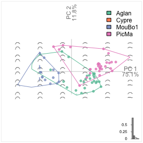

```
##         view
## var      VD VL
##   Aglan  30 30
##   Cypre  30  0
##   MouBo1 30 30
##   PicMa  30 30
```

```r
with(olea$fac, table(var, view))
# we drop 'Cypre' since there is no VL for 'Cypre' var
olea %>%
  filter(var != "Cypre") %>%
  # split, do morphometrics, combine
  chop(~view) %>% opoly %>% combine() %>%
  # note the two views in the morphospace
  PCA() %>% plot_PCA(~var)
```

### Various helpers

Some methods help, on `Coe` objects to: * select groups with at least a certain number of individuals in them: `at_least` * removes outliers : `which_out` * sample a given number: `sample_n`; * sample a given proportion: `sample_frac`; * generate new individuals based on calibrated Gaussian coefficient generation: `breed`; * generate new individuals based on permutations: `perm`.

Several shortcuts are implemented on `Coo` and `Coe` objects: * `names` returns shape names; * `length` returns their number; * `Ntable` does the same job and plots a confusion matrix; * `[]` extracts one (or more) shape; * `$` can access either a shape name or a column name for the `$fac`.

Try the following:

```r
names(bot)
length(bot)
bot[1]
bot[1:5]
bot$brahma
bot$type
```

## Babel import/export

There are various morphometrics formats in the wild, almost as much as softwares. Momocs tries to create bridges between them, all gathered in the **Babel** family.

Note that these will move to [**Momit**](https://momx.github.io/Momit/)/[**Momecs**](https://momx.github.io/Momecs/) asap.

### Bridges within R

You can convert from/to array, matrix, list or data.frame with the functions `{a, m, l, d}2{a, m, l, d}`. For instance, `l2a` converts a list into an array that you can use with `geomorph`; `a2l` does the inverse operation.

Imagine you want to import pupfish from `geomorph` as a `Ldk` object:

```r
library(geomorph)
data(pupfish)
str(pupfish)
# so $coords will become $coo, and
# all other components will be turned into a data.frame to feed $fac
# with a single line
Ldk(coo=pupfish$coords %>% a2l,
    fac=pupfish[-1] %>% as.data.frame())
```

### Import from StereoMorph

If you use StereoMorph to digitize landmarks and curves, you can import them, from the files produced with the functions `import_StereoMorph_ldk` and `import_StereoMorph_curve`.

### Import from tps and other digitizing softwares

- `.tps` files can be read with `import_tps`
- `.nts` files an be read with `nts2Coo` (will be turned into `import_nts` soon)

### Direct build of *Coe objects

You’re not bound with Momocs from the “shapes” step, ie you do not have to start from `Coo` objects. For instance if you have a matrix of coefficients, you can directly build an `OutCoe` with the builder (see below). Same approach for `OpnCoe` and `TraCoe`; have a look to the help files of these builders.

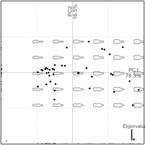

```r
# we simulate an imported matrix of coordinates, eg from a .csv
coeffs_from_the_wild <- bot %>% efourier(6) %$% coe
coeffs_in_Momocs <- OutCoe(coe=coeffs_from_the_wild, method="efourier", norm=TRUE)
coeffs_in_Momocs %>% PCA %>% plot
```

### Import misc

- If covariables are encoded in filenames, which is a good practice, eg if you have files named `spA_group7_ind4_VL.{txt|jpg|etc.}`, use `lf_structure`;
- If you need rewriting rules on your `$fac`, `rw_rule` is your friend;
- If you need to rescale imported coordinates, see `rescale`;
- If you need to tie images (eg outlines) and `.txt` (eg coordinates of landmarks on them), see `tie_jpg_txt`.

### Save from R

The best way to save a Momocs object is probably to use the base `save` function. You can call it back afterwards with `load`:

```r
save(bot, file="Bottles.rda")
# closing R, going to the beach, back at work
load("Bottles.rda") # bot is back
```

### Export from R

Any Momocs object, `Coo`s, `Coe`s, `PCA`s, etc. can be turned into a `data.frame` with `as_df`.

```r
bot %>% as_df
bot %>% efourier %>% as_df
bot %>% efourier %>% PCA %>% as_df
```

```
## # A tibble: 40 × 4
##    coo             type   fake     cs
##    <named list>    <fct>  <fct> <dbl>
##  1 <dbl [138 × 2]> whisky a      364.
##  2 <dbl [168 × 2]> whisky a      333.
##  3 <dbl [189 × 2]> whisky a      232.
##  4 <dbl [129 × 2]> whisky a      267.
##  5 <dbl [152 × 2]> whisky a      300.
##  6 <dbl [161 × 2]> whisky a      220.
##  7 <dbl [124 × 2]> whisky a      290.
##  8 <dbl [126 × 2]> whisky a      268.
##  9 <dbl [183 × 2]> whisky a      257.
## 10 <dbl [193 × 2]> whisky a      353.
## # … with 30 more rows
## # A tibble: 40 × 43
##    type   fake     cs    A1      A2     A3     A4      A5      A6       A7
##    <fct>  <fct> <dbl> <dbl>   <dbl>  <dbl>  <dbl>   <dbl>   <dbl>    <dbl>
##  1 whisky a      364.     1 0.00677 0.0935 0.0137 0.0238  0.00859  0.00318
##  2 whisky a      333.     1 0.00737 0.0954 0.0145 0.0222  0.00667  0.00355
##  3 whisky a      232.     1 0.0165  0.0757 0.0274 0.00988 0.0143  -0.00474
##  4 whisky a      267.     1 0.00749 0.0962 0.0122 0.0229  0.00728  0.00550
##  5 whisky a      300.     1 0.0196  0.0928 0.0223 0.0153  0.0149   0.00252
##  6 whisky a      220.     1 0.0222  0.0690 0.0335 0.00932 0.0211  -0.00169
##  7 whisky a      290.     1 0.00731 0.0911 0.0129 0.0231  0.0106   0.00458
##  8 whisky a      268.     1 0.00952 0.0857 0.0197 0.0129  0.00849 -0.00220
##  9 whisky a      257.     1 0.00959 0.0883 0.0227 0.0178  0.0107  -0.00152
## 10 whisky a      353.     1 0.00960 0.0919 0.0139 0.0201  0.00895  0.00240
## # … with 30 more rows, and 33 more variables: A8 <dbl>, A9 <dbl>, A10 <dbl>,
## #   B1 <dbl>, B2 <dbl>, B3 <dbl>, B4 <dbl>, B5 <dbl>, B6 <dbl>, B7 <dbl>,
## #   B8 <dbl>, B9 <dbl>, B10 <dbl>, C1 <dbl>, C2 <dbl>, C3 <dbl>, C4 <dbl>,
## #   C5 <dbl>, C6 <dbl>, C7 <dbl>, C8 <dbl>, C9 <dbl>, C10 <dbl>, D1 <dbl>,
## #   D2 <dbl>, D3 <dbl>, D4 <dbl>, D5 <dbl>, D6 <dbl>, D7 <dbl>, D8 <dbl>,
## #   D9 <dbl>, D10 <dbl>
## # A tibble: 40 × 43
##    type   fake     cs     PC1       PC2      PC3       PC4       PC5       PC6
##    <fct>  <fct> <dbl>   <dbl>     <dbl>    <dbl>     <dbl>     <dbl>     <dbl>
##  1 whisky a      364. -0.0528 -0.0231    0.00245 -0.0154    0.00605  -0.000973
##  2 whisky a      333. -0.0369  0.00725  -0.00866 -0.00921  -0.00277  -0.00282
##  3 whisky a      232.  0.0809 -0.00479  -0.00222 -0.0107   -0.000996 -0.00691
##  4 whisky a      267. -0.0694  0.00229  -0.0158  -0.00619  -0.000309  0.00386
##  5 whisky a      300. -0.0112  0.0476   -0.0127   0.0175    0.0135   -0.00699
##  6 whisky a      220.  0.115  -0.0170   -0.0103  -0.00912   0.000377  0.00126
##  7 whisky a      290. -0.0443 -0.0186   -0.00496 -0.000223  0.00190   0.00322
##  8 whisky a      268.  0.0287  0.00996  -0.0114  -0.00872  -0.00446  -0.00423
##  9 whisky a      257.  0.0123  0.000603  0.00364 -0.00819  -0.00391   0.000376
## 10 whisky a      353. -0.0458  0.00564  -0.00889 -0.00525   0.00399  -0.00242
## # … with 30 more rows, and 34 more variables: PC7 <dbl>, PC8 <dbl>, PC9 <dbl>,
## #   PC10 <dbl>, PC11 <dbl>, PC12 <dbl>, PC13 <dbl>, PC14 <dbl>, PC15 <dbl>,
## #   PC16 <dbl>, PC17 <dbl>, PC18 <dbl>, PC19 <dbl>, PC20 <dbl>, PC21 <dbl>,
## #   PC22 <dbl>, PC23 <dbl>, PC24 <dbl>, PC25 <dbl>, PC26 <dbl>, PC27 <dbl>,
## #   PC28 <dbl>, PC29 <dbl>, PC30 <dbl>, PC31 <dbl>, PC32 <dbl>, PC33 <dbl>,
## #   PC34 <dbl>, PC35 <dbl>, PC36 <dbl>, PC37 <dbl>, PC38 <dbl>, PC39 <dbl>,
## #   PC40 <dbl>
```

If the heretic you want to exit R to do stats elsewhere, `export` is your friend:

```r
bot %>% efourier %>% export
bot %>% efourier %>% PCA %>% export
```

But, of course, you can directly access information within the Momocs objects; try the following:

```r
# from Coo objects
bot$coo # list of matrices (of xy coordinates)
bot$fac # data.frame for covariates

# from Coe objects
bot.f$coe # matrix of coefficients
bot.f$fac # data.frame for covariates

# from PCA objects
bot.p$x        # scores
bot.p$rotation # rotation matrix
```

## Graphics

Most graphics are currently being rewritten, either to pure `ggplot2` or using grindr. See the dedicated embryo of vignette: see `vignette("Momocs_grindr")`.

### `tps_*`: Thin Plate Splines

TPS have not been presented before but here there are:

```
tps_grid(beer, whisky)
tps_arr(beer, whisky)
tps_iso(beer, whisky)
```

Again, plenty options in `?tps_*`.

You may also like lolliplots and friends:

```r
coo_lolli(beer, whisky); title("coo_lolli")
coo_arrows(beer, whisky); title("coo_arrow")

# an example with coo_ruban
coo_plot(beer) # to get the first plot
coo_ruban(beer, edm(beer, whisky), lwd=8) # we add ruban based from deviations
coo_draw(whisky)
title("coo_ruban")
```

### Color palettes

- Nice palettes are bundled with Momocs, see `?palettes`.

## Frequently asked questions

See `vignette("Momocs_FAQ")`.

- Done with love by Vincent Bonhomme `<bonhomme.vincent@gmail.com>`.
- Help/suggestions/review/critics are welcome.
- Sources are [there](https://github.com/MomX/Momocs/tree/master/vignettes)